# 4482_Tutorial_Regression_EDA

# compute the correlation matrix

```python
# compute correlation
cor = car_mpg[['mpg', 'cylinders', 'displacement', 'horsepower', 'weight',
       'acceleration', 'model_year']].corr()

cor
```

[output not shown]

# heatmap of correlation

this plot is a useful way to visualize which correlations are the most significant, and also to identify possible co-linearity between predictors.

red are positive correlations and blue are negative correlations

```
[]
```

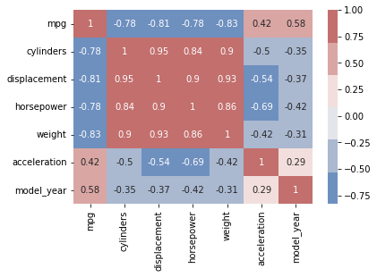

```python
# plot the heatmap
sns.heatmap(cor,
            annot=True,
            cmap=sns.color_palette("vlag"),
        xticklabels=cor.columns,
        yticklabels=cor.columns)

plt.plot()
```

# show the correlation

```python
cor['mpg'].sort_values(ascending=False)
```

```
mpg             1.000000
model_year      0.580541
acceleration    0.423329
cylinders      -0.777618
horsepower     -0.778427
displacement   -0.805127
weight         -0.832244
Name: mpg, dtype: float64
```

# positive correlation

-1 and 1 are the maximum values. The absolute value indicates the strength of the correlation. Larger absolute value = stronger correlation.

The correlation sign (+-) is strongly indicative of the slope you will likely find when computing a regression.

the following code filters for only correlation values greater than 0

**interpreting the results below**

model year appears to have the strongest positive correlation, while acceleration has the lowest positive correlation.

any column's correlation with itself will always be 1

```python
cor[cor['mpg']>0]['mpg'].sort_values(ascending=False)
```

```
mpg             1.000000
model_year      0.580541
acceleration    0.423329
Name: mpg, dtype: float64
```

# negative correlation

the following code filters for only correlation values less than 0

weight appears to have the strongest negative correlation, while cylinders has the lowest negative correlation.

```python
cor[cor['mpg']<0]['mpg'].sort_values(ascending=True)
```

```
weight         -0.832244
displacement   -0.805127
horsepower     -0.778427
cylinders      -0.777618
Name: mpg, dtype: float64
```

stats model allows us to perform a single regression for one predictor an outcome. it does not allow multiple regression (multiple predictors). But for this investigation we'd like to see each predictor and our outcome separately.

```
r2_value 0.6926304331206254
p value 6.015296051435726e-102
coef -0.007647342535779578
```

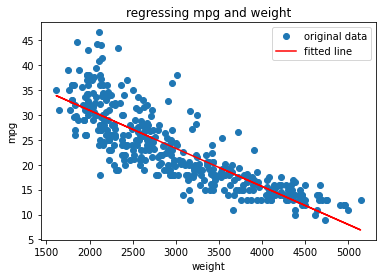

```python
predictor = 'weight'

# create the regression using the predictor and the target
model = stats.linregress(car_mpg[predictor], car_mpg['mpg'])

# print some of the model output
print("r2_value",model.rvalue**2)
print("p value",model.pvalue)
print("coef",model.slope)

# plot the model's regression line on top of our data to
# see how well it 'fits'
plt.plot(car_mpg[predictor], car_mpg['mpg'], 'o', label='original data')
plt.plot(car_mpg[predictor], model.intercept + model.slope*car_mpg[predictor], 'r', label='fitted line')
plt.legend()
plt.title(f'regressing mpg and {predictor}')
plt.xlabel(predictor)
plt.ylabel('mpg')
plt.show()
```

```python
predictor = 'horsepower'

model = stats.linregress(car_mpg[predictor], car_mpg['mpg'])
print("r2",model.rvalue**2)
print("p value",model.pvalue)
print("coef",model.slope)

plt.plot(car_mpg[predictor], car_mpg['mpg'], 'o', label='original data')
plt.plot(car_mpg[predictor], model.intercept + model.slope*car_mpg[predictor], 'r', label='fitted line')
plt.legend()
plt.title(f'regressing mpg and {predictor}')
plt.xlabel(predictor)
plt.ylabel('mpg')
plt.show()
```

```
r2 0.6059482578894345
p value 7.031989029405463e-81
coef -0.15784473335365348
```

```python
predictor = 'model_year'

model = stats.linregress(car_mpg[predictor], car_mpg['mpg'])
print("r2",model.rvalue**2)
print("p value",model.pvalue)
print("coef",model.slope)

plt.plot(car_mpg[predictor], car_mpg['mpg'], 'o', label='original data')
plt.plot(car_mpg[predictor], model.intercept + model.slope*car_mpg[predictor], 'r', label='fitted line')
plt.legend()
plt.title(f'regressing mpg and {predictor}')
plt.xlabel(predictor)
plt.ylabel('mpg')
plt.show()
```

```
r2 0.3370278133096226
p value 1.0757935564158799e-36
coef 1.2300354634480308
```

# removing redundant code with a function

It's getting clear that this needs to be repeated for each predictor. let's create a function to simplify.

We take the code from before and nest it inside a function. We can then pass the string for the predictor in as the first argument, and our dataframe in as the second argument.

If we were doing this for an assignment we would likely have to change the target variable name in the function to make this work.

```python
def helper_fun(predictor,df):

  target = 'mpg'

  model = stats.linregress(df[predictor], df[target])
  print("r2",model.rvalue**2)
  print("p value",model.pvalue)
  print("coef",model.slope)
  plt.plot(df[predictor], df[target], 'o', label='original data')
  plt.plot(df[predictor], model.intercept + model.slope*df[predictor], 'r', label='fitted line')
  plt.legend()
  plt.title(f'regressing mpg and {predictor}')
  plt.xlabel(predictor)
  plt.ylabel(target)
  plt.show()
```

```python
helper_fun('model_year',car_mpg)
```

```
r2 0.3370278133096226
p value 1.0757935564158799e-36
coef 1.2300354634480308
```

```python
car_mpg.drop('origin',axis=1).columns # the function only works on numeric data, not categorical. drop origin
```

```
Index(['mpg', 'cylinders', 'displacement', 'horsepower', 'weight',
       'acceleration', 'model_year'],
      dtype='object')
```

This code creates a for loop through all of the columns except for origin. It iterates through each column in our dataframe and builds a model for each. This is much faster than building each model individually and a lot less code.

```
r2 1.0
p value 0.0
coef 1.0
```

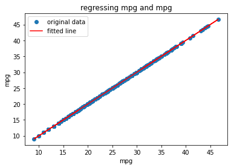

```
r2 0.604688988944123
p value 1.3113836370998321e-80
coef -3.558078367621495
```

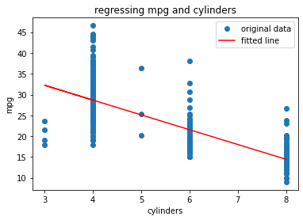

```
r2 0.6482294003193045
p value 1.6606418277975981e-90
coef -0.06005142781220625
```

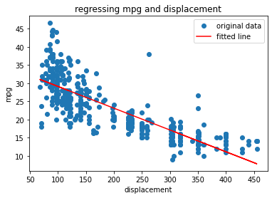

```
r2 0.6059482578894345
p value 7.031989029405463e-81
coef -0.15784473335365348
```

```
r2 0.6926304331206254
p value 6.015296051435726e-102
coef -0.007647342535779578
```

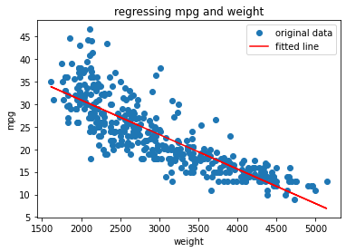

```
r2 0.17920705015625463
p value 1.7785761248041197e-18
coef 1.1976241877320564
```

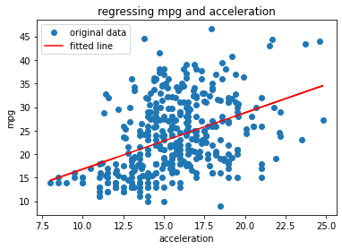

```
r2 0.3370278133096226
p value 1.0757935564158799e-36
coef 1.2300354634480308
```

```python
for col in car_mpg.drop('origin',axis=1).columns:
  helper_fun(col,car_mpg)
```

we can run the helper function for origin as well, we just need to dummy encode it like we normally do before modeling.

```python
cat_data = pd.get_dummies(car_mpg[['mpg','origin']])
cat_data.head()
```

|  | mpg | origin_Europe | origin_Japan | origin_USA |
| --- | --- | --- | --- | --- |
| 0 | 18.0 | 0 | 0 | 1 |
| 1 | 15.0 | 0 | 0 | 1 |
| 2 | 18.0 | 0 | 0 | 1 |
| 3 | 16.0 | 0 | 0 | 1 |
| 4 | 17.0 | 0 | 0 | 1 |

```
r2 0.31940649639450347
p value 1.8397072868720683e-34
coef -9.099863945578242
```

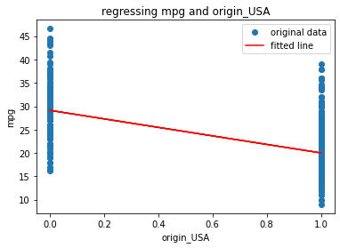

```python
helper_fun('origin_USA',cat_data)
```

```python
cat_data.groupby('origin_USA').mean() # the mean mpg for USA is ~20mpg, while not USA has a mean of ~29mpg!
```

| origin_USA | mpg | origin_Europe | origin_Japan |
| --- | --- | --- | --- |
| 0 | 29.133333 | 0.462585 | 0.537415 |
| 1 | 20.033469 | 0.000000 | 0.000000 |

```
r2 0.059688598137246765
p value 9.776543423053121e-07
coef 5.02948438634714
```

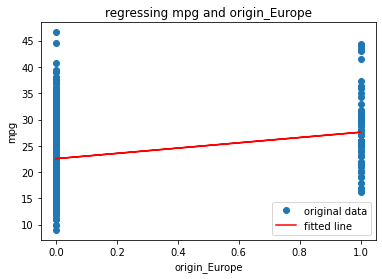

```python
helper_fun('origin_Europe',cat_data)
```

```python
cat_data.groupby('origin_Europe').mean()
```

| origin_Europe | mpg | origin_Japan | origin_USA |
| --- | --- | --- | --- |
| 0 | 22.573457 | 0.243827 | 0.756173 |
| 1 | 27.602941 | 0.000000 | 0.000000 |

```
r2 0.20381037997674437
p value 4.420895151852501e-21
coef 8.772677639826886
```

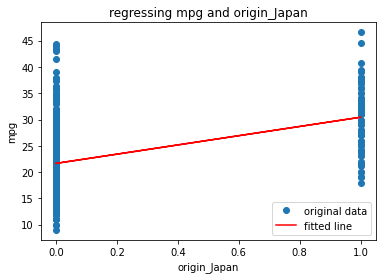

```python
helper_fun('origin_Japan',cat_data)
```

```python
cat_data.groupby('origin_Japan').mean()
```

| origin_Japan | mpg | origin_Europe | origin_USA |
| --- | --- | --- | --- |
| 0 | 21.677955 | 0.217252 | 0.782748 |
| 1 | 30.450633 | 0.000000 | 0.000000 |

```python
model.slope
```

```
1.2300354634480308
```

```python
import numpy as np
```

Using the values 29 and 20 for origin_USA 0 and 1 respectively inspect the graph. do you see where those values match the graph? not coincidentally they are exactly where the red line intersects the data for 0 and 1. Check Europe and Japan to check your understanding.

regression for categorical data simply involves finding the mean value for that category.

# understanding non-linearity and transforms

we are transforming horsepower here with a log function to see if this will fit the data better than the original feature. This is an example of a non-linear transform. Taking the square root would also be non-linear, or the raising to a power as well.

```python
new_car_mpg = car_mpg.copy()
new_car_mpg['horsepower_log'] = np.log(new_car_mpg['horsepower']) # we are taking the log of horsepower
```

```python
helper_fun('horsepower',new_car_mpg) # show the original fit to the untransformed horsepower
```

[output not shown]

```
r2 0.6059482578894345
p value 7.031989029405463e-81
coef -0.15784473335365348
```

```
r2 0.6683347641192137
p value 1.69658255433054e-95
coef -18.582184763050964
```

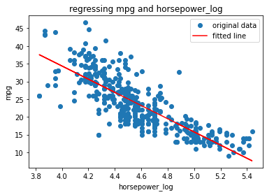

```python
helper_fun('horsepower_log',new_car_mpg) # now show the fit to the transformed horsepower. visually it looks a bit better
# and we can be sure it is better by comparing the r-squared value from the original to the transformed.
# If r-squared has increased our fit is likely improved
```

our new R squared suggests we have improved the overall fit of the line. We have changed the predictorwith a non-linear transform, and our result is a more linear results. But what does our x axis unit mean now? It could be translated back to the original units with the inverse of the transform we used but the casual observer will no longer easily be able to interpret horsepower.

Also, have ALL the dots gotten closer to the line in ALL cases? or have we made some worse? Transforms like this are often a tradeoff.

This is your first foray into a topic known as "Feature Engineering" in which you attempt to improve your model by creating new features based on the original data.

```python
!cp "/content/drive/My Drive/Colab Notebooks/4482_Tutorial_Regression_EDA.ipynb" ./

# run the second shell command, jupyter nbconvert --to html "file name of the notebook"
# create html from ipynb

!jupyter nbconvert --to html "4482_Tutorial_Regression_EDA.ipynb"
```

[output not shown]

[output cut: 108 more lines]

[output not shown]